# Model Building Techniques- CoGo Bike Share Data

Team - 03 (VISHESH BHATI, AMJAD ALTUWAYJIRI, SUZHE LI)

2022-12-15

[figure not shown]

# Why Bike sharing system?

While this system has many benefits, it also presents operators with a number of challenges, such as the best way to estimate demand. The data contains multiple features to explore which helped us to learn about the business and how to use analytics for the same.

# Problem statement

How can CoGo bike-sharing company boost their profit margins by implementing particular adjustments, such as increasing or removing specific bike kinds, growing its business in a specific location, or lowering or raising the cost of bike share?

```r
#binding all the files in this path together
file.list <- list.files(pattern='*.csv')

file.list <- setNames(file.list, file.list)

bike <-map_df(file.list, function(x) read.csv(x))
```

# Source of dataset and observation

We found the data on CoGo website. They have made the CoGo’s trip data available for public use. The dataset is real-time data with 13 columns and 39462 rows covering 6 months of data (Quarter 2 and Quarter 3) [Not covering the entire year due to the large size of the data].

```r
str(bike)
```

```
## 'data.frame':    39462 obs. of  13 variables:
##  $ ride_id           : chr  "EAE5DE3B6088243F" "A192FF580356253A" "13471B2AD5728280" "72C8BB899AF9ABD9" ...
##  $ rideable_type     : chr  "classic_bike" "classic_bike" "classic_bike" "electric_bike" ...
##  $ started_at        : chr  "2022-05-23 16:58:56" "2022-05-11 13:11:19" "2022-05-30 10:27:43" "2022-05-27 00:50:20" ...
##  $ ended_at          : chr  "2022-05-23 16:58:58" "2022-05-11 13:45:42" "2022-05-30 10:33:15" "2022-05-27 00:59:18" ...
##  $ start_station_name: chr  "Dorrian Commons - Mound St" "Neil Ave & King Ave" "Grant Ave & Main St" "Neil Ave & King Ave" ...
##  $ start_station_id  : num  5 54 15 54 54 23 23 73 29 54 ...
##  $ end_station_name  : chr  "Dorrian Commons - Mound St" "Library - Whetstone Branch" "Columbus College of Art & Design" "Neil Ave & King Ave" ...
##  $ end_station_id    : num  5 110 26 54 54 93 93 74 14 72 ...
##  $ start_lat         : num  40 40 40 40 40 ...
##  $ start_lng         : num  -83 -83 -83 -83 -83 ...
##  $ end_lat           : num  40 40 40 40 40 ...
##  $ end_lng           : num  -83 -83 -83 -83 -83 ...
##  $ member_casual     : chr  "member" "casual" "member" "member" ...
```

# Features in the dataset

Below are all the column names of the dataset

```r
colnames(bike)
```

```
##  [1] "ride_id"            "rideable_type"      "started_at"
##  [4] "ended_at"           "start_station_name" "start_station_id"
##  [7] "end_station_name"   "end_station_id"     "start_lat"
## [10] "start_lng"          "end_lat"            "end_lng"
## [13] "member_casual"
```

# SMART question and how did they come up?

**For Part-1** **(Exploratory data analysis)** How can the CoGo bike-sharing company boost their profit margins by implementing particular adjustments, such as increasing or removing specific bike kinds, growing its business in a specific location, or lowering or raising the cost of bike share?

**For Part-2 (Model Building Techniques)**

1. How much time will the customer (Annual membership or Casual) ride the bike if travelling from a certain station to another or using a certain bike etc?
2. Which Bike type (Electric or Manual) will the customer (Annual membership or Casual) use if travelling from a certain station to another/while using a certain bike type or during certain time-interval etc?
3. What type of customer (Annual membership or Casual) will travel from a certain station to another, while using a certain bike type, or traveling from a certain station etc?

We mainly want to predict Customer Type, Bike Type and Ride time using multiple features available in the data. COGO company can use these prediction models to understand their customer behavior and can tweak their business model from the information to gain more profit.

We found a lot of analytics being performed on the bike sharing data on internet, but in all the analysis focus was just on the data. We also wanted to include the business perspective and wanted to see how this can finally help the company and hence we thought of the above-mentioned SMART questions.

# Project 1 (EDA) - revisit

In project-1 (EDA), we only used 1 month of data (August 2022), but in project-2 we are using 6 months of the data. We re-performed the EDA with the similar code as last time but with 6 months of data and compared the results of both 1 month and 6 month data

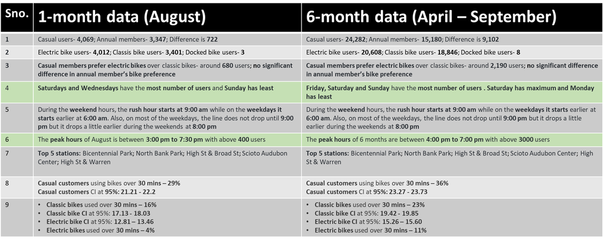

We only found major changes in point 4 and point 6 (highlighted in the above table)

# Data Pre-Processing:

## Balancing the data

Data contains 3 types of bikes- Classic, Electric and Docked. We are removing docked bike from the data to balance the data as the data contains only 8 docked bikes over 39000+ observations.

```r
bike%>%group_by(rideable_type)%>%
  summarise(count = n())
```

```
## # A tibble: 3 × 2
##   rideable_type count
##   <chr>         <int>
## 1 classic_bike  18846
## 2 docked_bike       8
## 3 electric_bike 20608
```

```r
#Remove docked bikes
bike <-subset(bike, rideable_type != "docked_bike")
bike%>%group_by(rideable_type)%>%
  summarise(count = n())
```

```
## # A tibble: 2 × 2
##   rideable_type count
##   <chr>         <int>
## 1 classic_bike  18846
## 2 electric_bike 20608
```

## Data type conversion

We converted categorical variables into factor and features containing time information into date-time format and further dates into minutes as numeric format for specific features as we would need them in the models.

```r
bike$rideable_type <- factor(ifelse(bike$rideable_type=="classic_bike",0,1))
bike$start_station_id <- factor(bike$start_station_id)
bike$end_station_id <- factor(bike$end_station_id)
bike$member_casual<-factor(ifelse(bike$member_casual=='casual',0,1))

bike$start_time <- format(as.POSIXct(bike$started_at), format = "%H:%M")
bike$end_time <- format(as.POSIXct(bike$ended_at), format = "%H:%M")

#Converting time in minutes
res <- hm(bike$start_time)# format to 'hours:minutes'
bike$startingm <- hour(res)*60 + minute(res)
res <- hm(bike$end_time)# format to 'hours:minutes'
bike$endingm <- hour(res)*60 + minute(res)

str(bike)
```

```
## 'data.frame':    39454 obs. of  17 variables:
##  $ ride_id           : chr  "EAE5DE3B6088243F" "A192FF580356253A" "13471B2AD5728280" "72C8BB899AF9ABD9" ...
##  $ rideable_type     : Factor w/ 2 levels "0","1": 1 1 1 2 2 1 1 1 1 1 ...
##  $ started_at        : chr  "2022-05-23 16:58:56" "2022-05-11 13:11:19" "2022-05-30 10:27:43" "2022-05-27 00:50:20" ...
##  $ ended_at          : chr  "2022-05-23 16:58:58" "2022-05-11 13:45:42" "2022-05-30 10:33:15" "2022-05-27 00:59:18" ...
##  $ start_station_name: chr  "Dorrian Commons - Mound St" "Neil Ave & King Ave" "Grant Ave & Main St" "Neil Ave & King Ave" ...
##  $ start_station_id  : Factor w/ 90 levels "1","2","3","4",..: 5 40 15 40 40 23 23 55 29 40 ...
##  $ end_station_name  : chr  "Dorrian Commons - Mound St" "Library - Whetstone Branch" "Columbus College of Art & Design" "Neil Ave & King Ave" ...
##  $ end_station_id    : Factor w/ 90 levels "1","2","3","4",..: 5 84 26 40 40 74 74 56 14 54 ...
##  $ start_lat         : num  40 40 40 40 40 ...
##  $ start_lng         : num  -83 -83 -83 -83 -83 ...
##  $ end_lat           : num  40 40 40 40 40 ...
##  $ end_lng           : num  -83 -83 -83 -83 -83 ...
##  $ member_casual     : Factor w/ 2 levels "0","1": 2 1 2 2 2 1 1 1 2 2 ...
##  $ start_time        : chr  "16:58" "13:11" "10:27" "00:50" ...
##  $ end_time          : chr  "16:58" "13:45" "10:33" "00:59" ...
##  $ startingm         : num  1018 791 627 50 1389 ...
##  $ endingm           : num  1018 825 633 59 1400 ...
```

## Adding new features

We created three new columns:

```r
# Fixing the date format to get the time difference
bike$Startedat = as.POSIXct(bike$started_at, format = "%Y-%m-%d %H:%M:%S")
bike$enddat = as.POSIXct(bike$ended_at, format = "%Y-%m-%d %H:%M:%S")

#Calculating the time difference
bike$Total_Time <- abs(as.numeric(difftime(bike$enddat, bike$Startedat, units = "mins")))

#days
bike$start_date <- as.Date(bike$started_at)
bike$end_date <- as.Date(bike$ended_at)
bike$days <- factor(format(bike$start_date, format = "%a"))

#Time-range
# Extract the 'Hours' only first, then change it to numeric variable
bike$start_hour <- format(as.POSIXct(bike$started_at), format = "%H")
bike$start_hour <- as.numeric(bike$start_hour)
# Use 'summary(bike$start_hour_num)' to check if the min and max are 0 and 23

# Divide the time into different categories/intervals
bike$Time_range <- cut(bike$start_hour, c(0, 6, 12, 18, 23), c("Before dawn", "Morning", "Afternoon", "Night"), include.lowest=TRUE)
#0am-6am : Morning (Factor 1)
#6am-12pm : Morning (Factor 2)
#12pm-18pm : Afternoon (Factor 3)
#6pm-0am : Night (Factor 4)

str(bike)
```

```
## 'data.frame':    39454 obs. of  25 variables:
##  $ ride_id           : chr  "EAE5DE3B6088243F" "A192FF580356253A" "13471B2AD5728280" "72C8BB899AF9ABD9" ...
##  $ rideable_type     : Factor w/ 2 levels "0","1": 1 1 1 2 2 1 1 1 1 1 ...
##  $ started_at        : chr  "2022-05-23 16:58:56" "2022-05-11 13:11:19" "2022-05-30 10:27:43" "2022-05-27 00:50:20" ...
##  $ ended_at          : chr  "2022-05-23 16:58:58" "2022-05-11 13:45:42" "2022-05-30 10:33:15" "2022-05-27 00:59:18" ...
##  $ start_station_name: chr  "Dorrian Commons - Mound St" "Neil Ave & King Ave" "Grant Ave & Main St" "Neil Ave & King Ave" ...
##  $ start_station_id  : Factor w/ 90 levels "1","2","3","4",..: 5 40 15 40 40 23 23 55 29 40 ...
##  $ end_station_name  : chr  "Dorrian Commons - Mound St" "Library - Whetstone Branch" "Columbus College of Art & Design" "Neil Ave & King Ave" ...
##  $ end_station_id    : Factor w/ 90 levels "1","2","3","4",..: 5 84 26 40 40 74 74 56 14 54 ...
##  $ start_lat         : num  40 40 40 40 40 ...
##  $ start_lng         : num  -83 -83 -83 -83 -83 ...
##  $ end_lat           : num  40 40 40 40 40 ...
##  $ end_lng           : num  -83 -83 -83 -83 -83 ...
##  $ member_casual     : Factor w/ 2 levels "0","1": 2 1 2 2 2 1 1 1 2 2 ...
##  $ start_time        : chr  "16:58" "13:11" "10:27" "00:50" ...
##  $ end_time          : chr  "16:58" "13:45" "10:33" "00:59" ...
##  $ startingm         : num  1018 791 627 50 1389 ...
##  $ endingm           : num  1018 825 633 59 1400 ...
##  $ Startedat         : POSIXct, format: "2022-05-23 16:58:56" "2022-05-11 13:11:19" ...
##  $ enddat            : POSIXct, format: "2022-05-23 16:58:58" "2022-05-11 13:45:42" ...
##  $ Total_Time        : num  0.0333 34.3833 5.5333 8.9667 10.9667 ...
##  $ start_date        : Date, format: "2022-05-23" "2022-05-11" ...
##  $ end_date          : Date, format: "2022-05-23" "2022-05-11" ...
##  $ days              : Factor w/ 7 levels "Fri","Mon","Sat",..: 2 7 2 1 5 4 4 4 4 4 ...
##  $ start_hour        : num  16 13 10 0 23 17 17 10 11 13 ...
##  $ Time_range        : Factor w/ 4 levels "Before dawn",..: 3 3 2 1 4 3 3 2 2 3 ...
```

## Feature selection

Selecting the features needed for the model

```r
#selecting the features needed for the model
selected_features <- c('member_casual','rideable_type', 'Total_Time', 'start_station_id', 'end_station_id', 'startingm','endingm','days', 'start_hour', 'Time_range')

bike2 <- bike[,(names(bike) %in% selected_features)]

str(bike2)
```

```
## 'data.frame':    39454 obs. of  10 variables:
##  $ rideable_type   : Factor w/ 2 levels "0","1": 1 1 1 2 2 1 1 1 1 1 ...
##  $ start_station_id: Factor w/ 90 levels "1","2","3","4",..: 5 40 15 40 40 23 23 55 29 40 ...
##  $ end_station_id  : Factor w/ 90 levels "1","2","3","4",..: 5 84 26 40 40 74 74 56 14 54 ...
##  $ member_casual   : Factor w/ 2 levels "0","1": 2 1 2 2 2 1 1 1 2 2 ...
##  $ startingm       : num  1018 791 627 50 1389 ...
##  $ endingm         : num  1018 825 633 59 1400 ...
##  $ Total_Time      : num  0.0333 34.3833 5.5333 8.9667 10.9667 ...
##  $ days            : Factor w/ 7 levels "Fri","Mon","Sat",..: 2 7 2 1 5 4 4 4 4 4 ...
##  $ start_hour      : num  16 13 10 0 23 17 17 10 11 13 ...
##  $ Time_range      : Factor w/ 4 levels "Before dawn",..: 3 3 2 1 4 3 3 2 2 3 ...
```

## Removing Null values and outliers

Removing outliers from column ‘Total_Time’

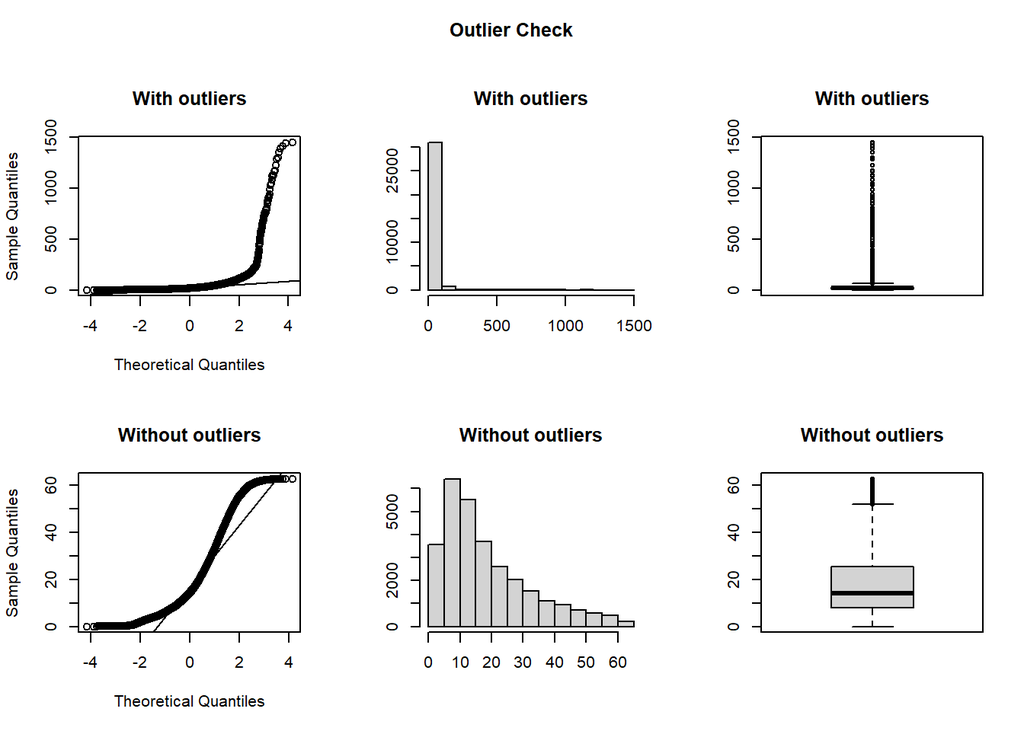

```
## Outliers identified: 2380
## Proportion (%) of outliers: 8.1
## Mean of the outliers: 121.09
## Mean without removing outliers: 26.15
## Mean if we remove outliers: 18.46
## Nothing changed
```

```r
#Removing NA values
bike2<-na.omit(bike2)

#Removing outliers from Total_Time
bike2 <- outlierKD2(bike2, Total_Time, boxplt = TRUE, qqplt = TRUE)
```

```r
print('Summary Statistic for Total time')
```

```
## [1] "Summary Statistic for Total time"
```

```r
summary(bike2)
```

```
##  rideable_type start_station_id end_station_id  member_casual   startingm
##  0:18739       1      : 2333    1      : 2458   0:19589       Min.   :   0.0
##  1:13021       92     : 1137    23     : 1092   1:12171       1st Qu.: 752.0
##                4      : 1098    4      : 1066                 Median : 977.0
##                23     :  951    92     : 1065                 Mean   : 930.4
##                13     :  794    45     :  750                 3rd Qu.:1151.0
##                19     :  735    20     :  735                 Max.   :1439.0
##                (Other):24712    (Other):24594
##     endingm         Total_Time        days        start_hour
##  Min.   :   0.0   Min.   :   0.000   Fri:4922   Min.   : 0.00
##  1st Qu.: 762.8   1st Qu.:   8.417   Mon:3357   1st Qu.:12.00
##  Median : 990.0   Median :  15.467   Sat:6989   Median :16.00
##  Mean   : 933.2   Mean   :  26.154   Sun:5706   Mean   :15.02
##  3rd Qu.:1166.0   3rd Qu.:  30.117   Thu:3686   3rd Qu.:19.00
##  Max.   :1439.0   Max.   :1447.083   Tue:3529   Max.   :23.00
##                                      Wed:3571
##        Time_range
##  Before dawn: 1802
##  Morning    : 6914
##  Afternoon  :14547
##  Night      : 8497
##
##
##
```

# SMART Questions 1.

How much time will the customer (Annual membership or Casual) ride the bike if travelling from a certain station to another or using a certain bike etc?

## Objective

We are going to use the newly created variable ‘Total_Time’ and want to make a fitted and predictive model for the customer’s riding time. This is because: 1). As we said before, COGO’s sharing bike price is defined by the riding time instead of riding distance. 2). If we can get some information from the model about what factors can affect customer’s riding time and how did they affect, for example, which customer type has more impact on the riding time, or, which bike type has more impact on the riding time…..etc. 3). Then, base on the pattern of factors affecting riding time from our model, we can make some recommendations for the company’s profit margin. 4). Moreover, if we can predict each customers riding time by the given information, then the company will know which customers will ride more and which customers will ride less, and they can do some other analysis about those customers whose gonna ride more in the future and use more marketing resources on them for making them into potential long-term loyal customers.

## Model structure

Because we want to predict the customer’s riding (in minutes), which is corresponding to the ‘Total_Time’ variable in the dataset, and it’s an numerical data, so Linear-Regression model become our first choice. We don’t want to try Regression Tree at first because it always have the problem of overfitting, accompany with the riding data is always changing and it changes fast (maybe have multiple new records of ride in next minutes), so we don’t want use a model that is easily overffiting. After we confirm which type of model we use, we will decide the dependent (response) variable and independent (regressors) variable of the model：We said the response variable is ‘Total_Time’ above and its numerical variable. Then, for choosing regressors, the variable we choose for LM here is almost the same, which are variables: ‘rideable_type’ that represents the which bike type the customer used, ‘member_casual’ that represents the customer’s membership status, and ‘days’ that represents what day did that customer use that bike; Except these variables above, for predicting the riding time, we believe the rider’s starting time will also affected the riding time, so we also added ‘start_hour’ variable into our model. For example, if I am starting at night, I may not want to spend so much time outside because it maybe unsafe, but if I am starting at afternoon, then maybe I will spend more time on sightseeing or something like that and won’t concern about the safety problem Then, we build our linear model based on this structure, and below is the fitting summary and the residual plots of this model.

```r
bike_lm <- data.frame(bike2)

bike_lm1 <- lm(formula = Total_Time ~ start_hour+rideable_type+member_casual+days, data=bike_lm)
summary(bike_lm1)
```

```
##
## Call:
## lm(formula = Total_Time ~ start_hour + rideable_type + member_casual +
##     days, data = bike_lm)
##
## Residuals:
##     Min      1Q  Median      3Q     Max
##  -40.45  -16.33   -6.36    4.31 1411.79
##
## Coefficients:
##                 Estimate Std. Error t value Pr(>|t|)
## (Intercept)     33.75720    1.12895  29.901  < 2e-16 ***
## start_hour       0.16145    0.05232   3.086 0.002031 **
## rideable_type1  -7.87741    0.54213 -14.530  < 2e-16 ***
## member_casual1 -19.19235    0.56107 -34.207  < 2e-16 ***
## daysMon          0.45834    1.06122   0.432 0.665815
## daysSat          0.53724    0.88495   0.607 0.543797
## daysSun          3.17742    0.92877   3.421 0.000624 ***
## daysThu         -1.46261    1.03310  -1.416 0.156858
## daysTue         -0.01458    1.04505  -0.014 0.988867
## daysWed         -0.08039    1.04299  -0.077 0.938564
## ---
## Signif. codes:  0 '***' 0.001 '**' 0.01 '*' 0.05 '.' 0.1 ' ' 1
##
## Residual standard error: 47.33 on 31750 degrees of freedom
## Multiple R-squared:  0.04404,    Adjusted R-squared:  0.04377
## F-statistic: 162.5 on 9 and 31750 DF,  p-value: < 2.2e-16
```

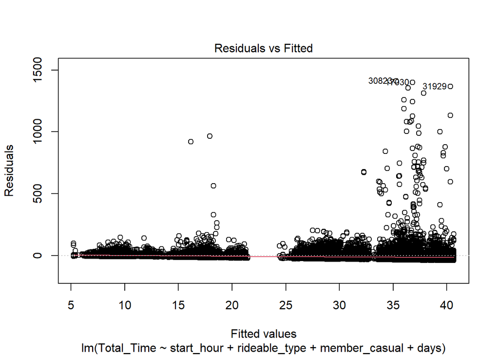

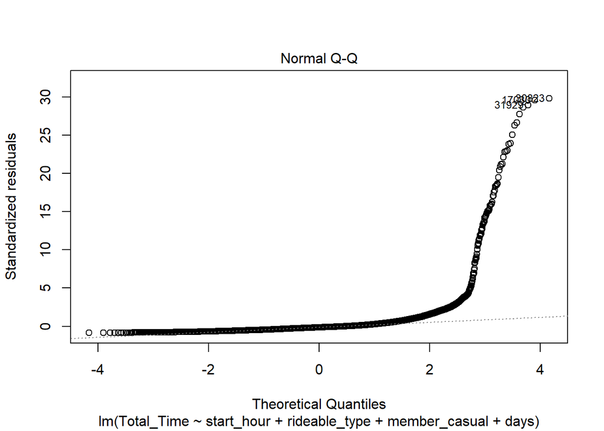

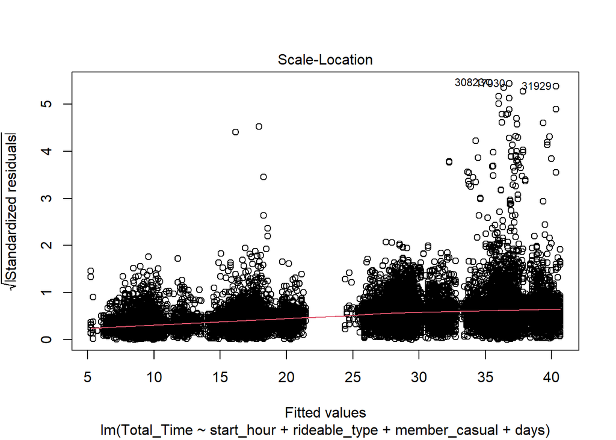

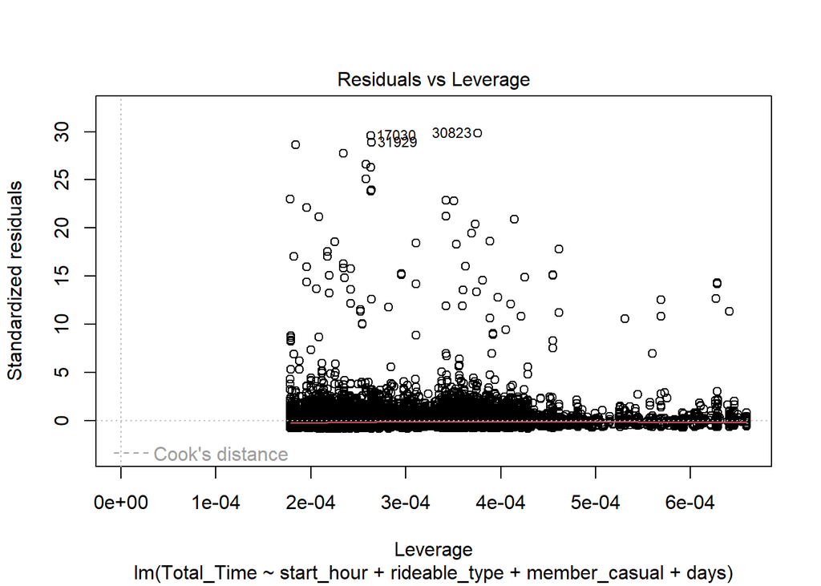

```r
plot(bike_lm1)
```

According to the fitting summary, though we have some significance coefficients and significant F-Statistic, the model fitting is really bad, because of the low R-Squared value. We only have 4% variation of response can be explained by our regressors, which indicate our response is hardly explained by the regressors currently. Moreover, according to the residual plots, we can clealy see that it’s not randomly scattered but with pattern.

## Model Assumptions Checking & Model Improvement:

Because these fitting information are really bad, we are trying to find the reason behind this before we make the conclusion by checking the model assumptions, and also try do something to see if we can improve this model:

### Multicollinearity check:

```r
library(car)
vif(bike_lm1)
```

```
##                   GVIF Df GVIF^(1/(2*Df))
## start_hour    1.015848  1        1.007893
## rideable_type 1.007983  1        1.003984
## member_casual 1.054917  1        1.027091
## days          1.057644  6        1.004681
```

Firstly, we check the vifs values to make sure all the regressors are independent with each other. As we see above, all the VIFs are less than 5, which means our regressors are midly correlate and this is acceptable, so we can conclude our current model doesn’t have the problem of multicollinearity.

### Normally Shaped check:

We need to make sure the dependent variable is (approximate) normal distributed. We can check the distribution of our response ‘Total_Time’ by building the its histogram

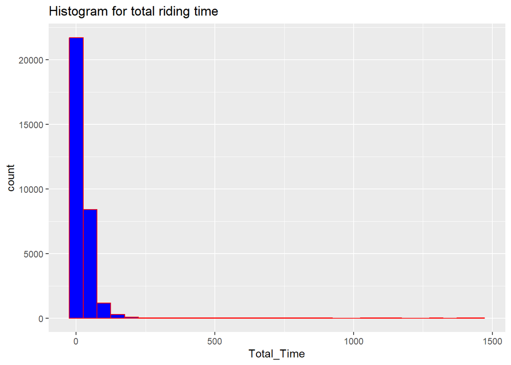

```r
# Double check the Total_Time distribution
ggplot(data=bike_lm, mapping = aes(Total_Time))+geom_histogram(col='red', fill='blue')+labs(title='Histogram for total riding time')
```

According to the distribution above, it’s highly right skewed and we can’t use the variable with this distribution to build the linear regression. This may be a reason that we get a so bad fittings. Thus, we will try to exclude all the outliers and build the regression again to see if we can improve the model’s fitting.

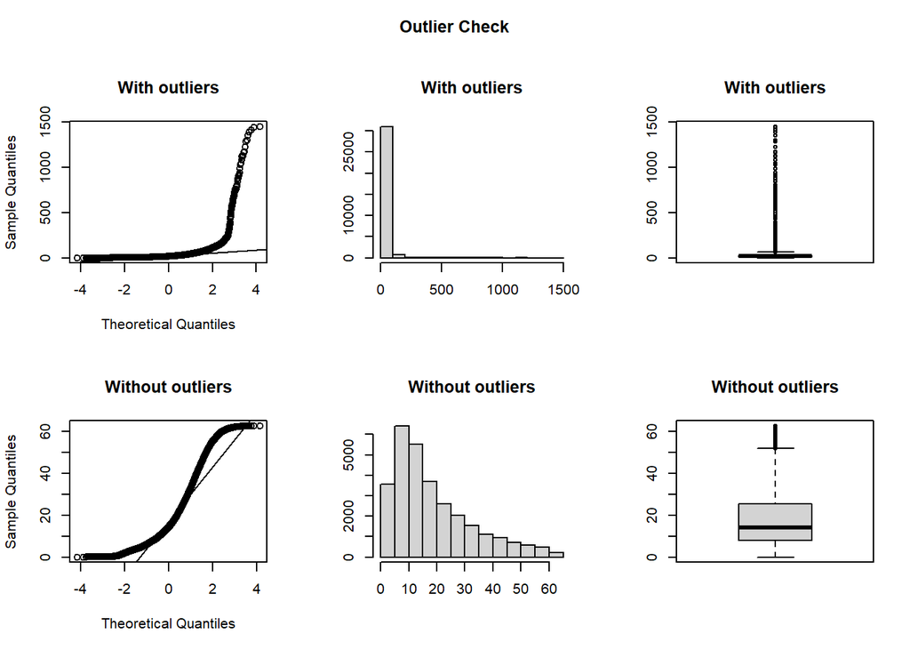

```
## Outliers identified: 2380
## Proportion (%) of outliers: 8.1
## Mean of the outliers: 121.09
## Mean without removing outliers: 26.15
## Mean if we remove outliers: 18.46
## Outliers successfully removed
```

```r
library(ezids)

bike_clean <- outlierKD2 (bike_lm, Total_Time, rm=T, boxplt = TRUE, qqplt = TRUE)
```

```r
print('Summary Statistic for cleaned membership time')
```

```
## [1] "Summary Statistic for cleaned membership time"
```

```r
summary(bike_lm$Total_Time)
```

```
##     Min.  1st Qu.   Median     Mean  3rd Qu.     Max.
##    0.000    8.417   15.467   26.154   30.117 1447.083
```

```r
# Double check the distribution
# ggplot(data=bike_clean, mapping = aes(Total_Time))+geom_histogram(col='red', fill='blue')+labs(title='Histogram for total riding time')
```

```r
bike_lm2 <- lm(formula = Total_Time ~ (start_hour+rideable_type+member_casual+days)^2, data=bike_clean)
summary(bike_lm2)
```

```
##
## Call:
## lm(formula = Total_Time ~ (start_hour + rideable_type + member_casual +
##     days)^2, data = bike_clean)
##
## Residuals:
##     Min      1Q  Median      3Q     Max
## -27.544  -9.016  -2.885   6.266  52.670
##
## Coefficients:
##                               Estimate Std. Error t value Pr(>|t|)
## (Intercept)                   20.83247    0.77448  26.899  < 2e-16 ***
## start_hour                     0.08543    0.04330   1.973  0.04851 *
## rideable_type1                -3.84556    0.64001  -6.009 1.89e-09 ***
## member_casual1                -7.87455    0.65033 -12.109  < 2e-16 ***
## daysMon                        0.95486    1.07265   0.890  0.37338
## daysSat                        2.24046    0.89515   2.503  0.01232 *
## daysSun                        1.35251    0.89191   1.516  0.12943
## daysThu                       -1.92653    1.07884  -1.786  0.07415 .
## daysTue                       -2.36080    1.10129  -2.144  0.03207 *
## daysWed                        0.82922    1.06228   0.781  0.43504
## start_hour:rideable_type1      0.08296    0.03036   2.733  0.00629 **
## start_hour:member_casual1     -0.02615    0.03181  -0.822  0.41107
## start_hour:daysMon             0.07037    0.06054   1.162  0.24506
## start_hour:daysSat            -0.08571    0.05048  -1.698  0.08953 .
## start_hour:daysSun             0.15969    0.05111   3.124  0.00178 **
## start_hour:daysThu             0.12967    0.05980   2.168  0.03014 *
## start_hour:daysTue             0.18529    0.06131   3.022  0.00251 **
## start_hour:daysWed            -0.04207    0.05919  -0.711  0.47722
## rideable_type1:member_casual1  0.43575    0.32597   1.337  0.18130
## rideable_type1:daysMon        -0.81306    0.61965  -1.312  0.18949
## rideable_type1:daysSat         0.04692    0.51287   0.091  0.92711
## rideable_type1:daysSun        -0.31398    0.54584  -0.575  0.56515
## rideable_type1:daysThu         0.44429    0.59829   0.743  0.45772
## rideable_type1:daysTue         0.15634    0.61128   0.256  0.79814
## rideable_type1:daysWed        -1.01632    0.60681  -1.675  0.09397 .
## member_casual1:daysMon        -1.97620    0.61699  -3.203  0.00136 **
## member_casual1:daysSat         0.60489    0.53519   1.130  0.25838
## member_casual1:daysSun        -1.28873    0.56421  -2.284  0.02237 *
## member_casual1:daysThu        -1.21500    0.59939  -2.027  0.04267 *
## member_casual1:daysTue        -1.54186    0.60921  -2.531  0.01138 *
## member_casual1:daysWed        -0.51556    0.60344  -0.854  0.39290
## ---
## Signif. codes:  0 '***' 0.001 '**' 0.01 '*' 0.05 '.' 0.1 ' ' 1
##
## Residual standard error: 13.05 on 29349 degrees of freedom
##   (2380 observations deleted due to missingness)
## Multiple R-squared:  0.1236, Adjusted R-squared:  0.1227
## F-statistic: 137.9 on 30 and 29349 DF,  p-value: < 2.2e-16
```

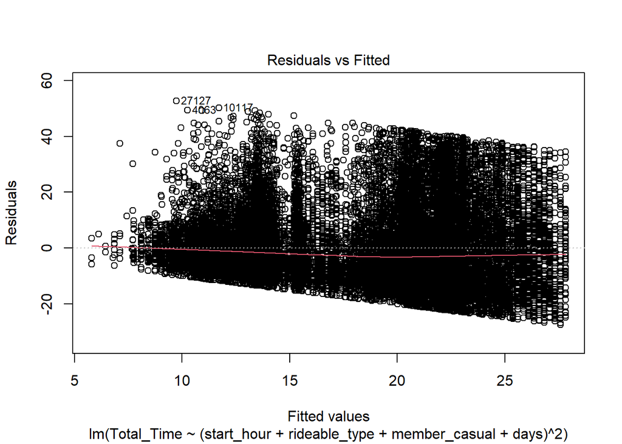

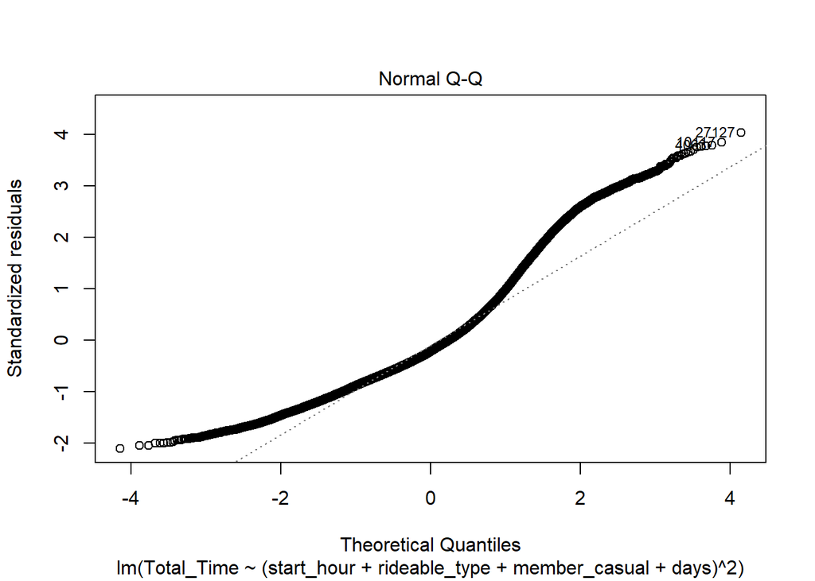

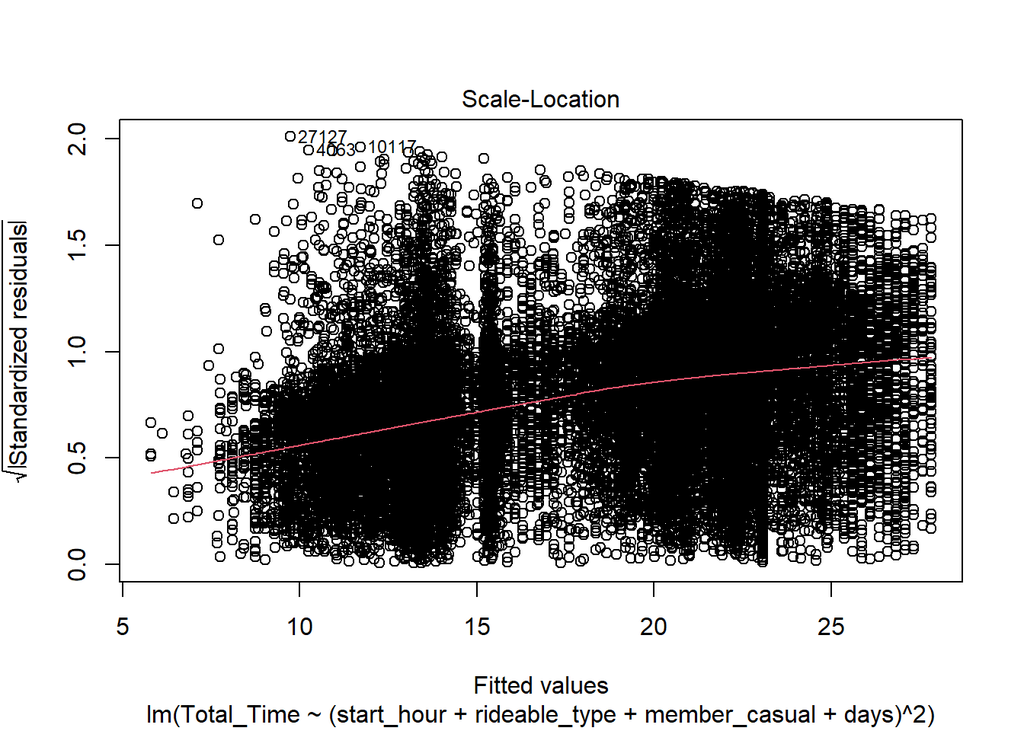

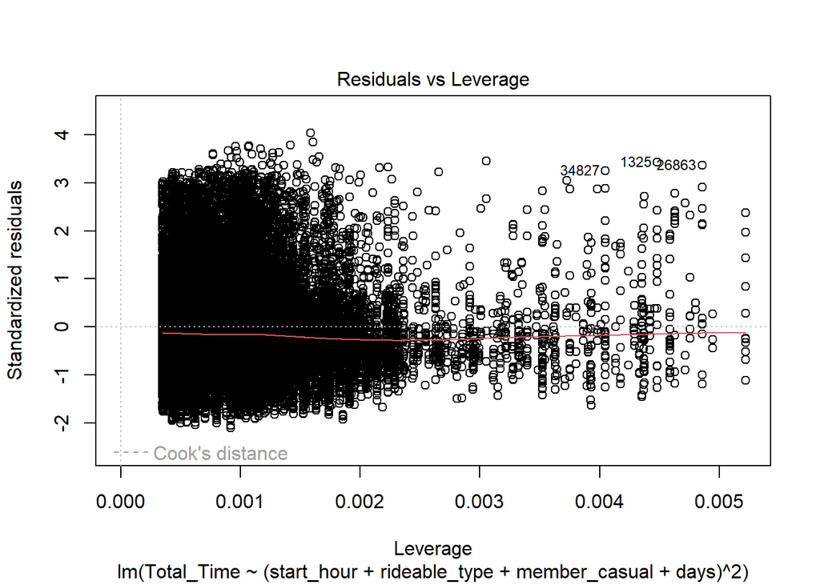

```r
plot(bike_lm2)
```

The model are better after we remove the outliers and the R-Squared values are went up a little bit. However, most of the models are still not having a good fitting , so we will keep checking other assumptions of linear model

### Linearity check

Then, we will check the linearity by building the scatter plot between total time and the only numerical variable ‘start_hour’

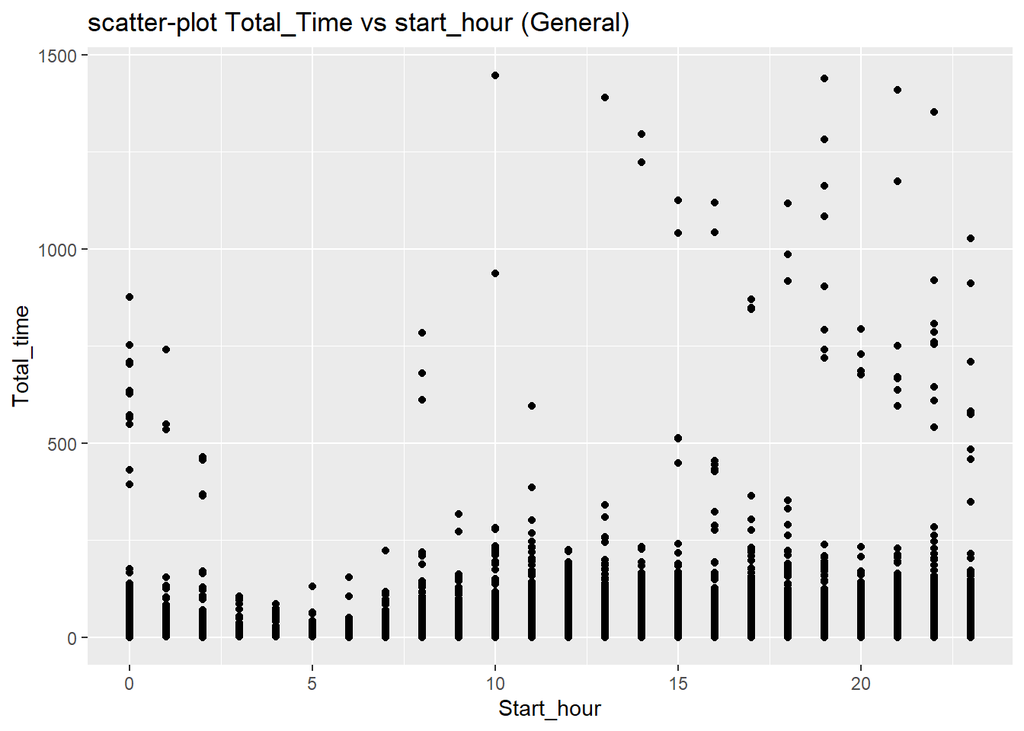

```r
library(ggplot2)

qplot (x=start_hour, y=Total_Time, data=bike_lm, xlab='Start_hour', ylab='Total_time', main='scatter-plot Total_Time vs start_hour (General)')
```

Base on the scatter plot above, we can see there’s totally no linear relationship with these two variable, but we can keep checking that if there’s a linear relationship between these two variables in different time range (Before dawn, Morning, Afternoon, Night)

[figure not shown]

```r
bike_clean_before_dawn <- subset(bike_clean, Time_range=='Before dawn')
bike_clean_morning <- subset(bike_clean, Time_range=='Morning')
bike_clean_afternoon <- subset(bike_clean, Time_range =='Afternoon')
bike_clean_night <- subset(bike_clean, Time_range=='Night')

qplot (x=Total_Time, y=start_hour, data=bike_clean_before_dawn, xlab='Start_hour', ylab='Total_time', main='scatter-plot Total_Time vs start_hour (Before dawn)')
```

[figure not shown]

```r
qplot (x=Total_Time, y=start_hour, data=bike_clean_morning, xlab='Start_hour', ylab='Total_time', main='scatter-plot Total_Time vs start_hour (Morning)')
```

[figure not shown]

```r
qplot (x=Total_Time, y=start_hour, data=bike_clean_afternoon, xlab='Start_hour', ylab='Total_time', main='scatter-plot Total_Time vs start_hour (Afternoon)')
```

[figure not shown]

```r
qplot (x=Total_Time, y=start_hour, data=bike_clean_night, xlab='Start_hour', ylab='Total_time', main='scatter-plot Total_Time vs start_hour (Night)')
```

We see there’s still not any linear relationship between total time and starting hour. However, we can’t build a linear regression with only categorical variable, so we can’t exclude this variable

# SMART Question 2.

Which Bike type (Electric or Manual) will the customer (Annual membership or Casual) use if travelling from a certain station to another, while using a certain bike type or at certain time etc?

We used 2 model to answer this question:

1. Logistic Regression
2. KNN

## Model-1: Logistic Regression (for Bike Type)

Firstly, we made the Rideable_type column as the first column in the dataset to make it easy while splitting the data for the modelling

```r
#Copying data for the model
bike_RT_LR <- data.frame(bike2)

#making rideable_type the first column

colnames(bike_RT_LR)
```

```
##  [1] "rideable_type"    "start_station_id" "end_station_id"   "member_casual"
##  [5] "startingm"        "endingm"          "Total_Time"       "days"
##  [9] "start_hour"       "Time_range"
```

```r
bike_RT_LR <- bike_RT_LR %>%
  select('rideable_type', everything())

print(head(bike_RT_LR))
```

```
##   rideable_type start_station_id end_station_id member_casual startingm endingm
## 1             0                5              5             1      1018    1018
## 2             0               54            110             0       791     825
## 3             0               15             26             1       627     633
## 4             1               54             54             1        50      59
## 5             1               54             54             1      1389    1400
## 6             0               23             93             0      1056    1074
##    Total_Time days start_hour  Time_range
## 1  0.03333333  Mon         16   Afternoon
## 2 34.38333333  Wed         13   Afternoon
## 3  5.53333333  Mon         10     Morning
## 4  8.96666667  Fri          0 Before dawn
## 5 10.96666667  Thu         23       Night
## 6 18.50000000  Sun         17   Afternoon
```

We further Checked, if we have unbalanced data. We found that the data was balanced and we could use it for our modeling

```r
# Checking for unbalanced data
bike_RT_LR%>%group_by(rideable_type)%>%
  summarise(count = n())
```

```
## # A tibble: 2 × 2
##   rideable_type count
##   <fct>         <int>
## 1 0             18739
## 2 1             13021
```

```r
bike_RT_LR %>% count(rideable_type)
```

```
##   rideable_type     n
## 1             0 18739
## 2             1 13021
```

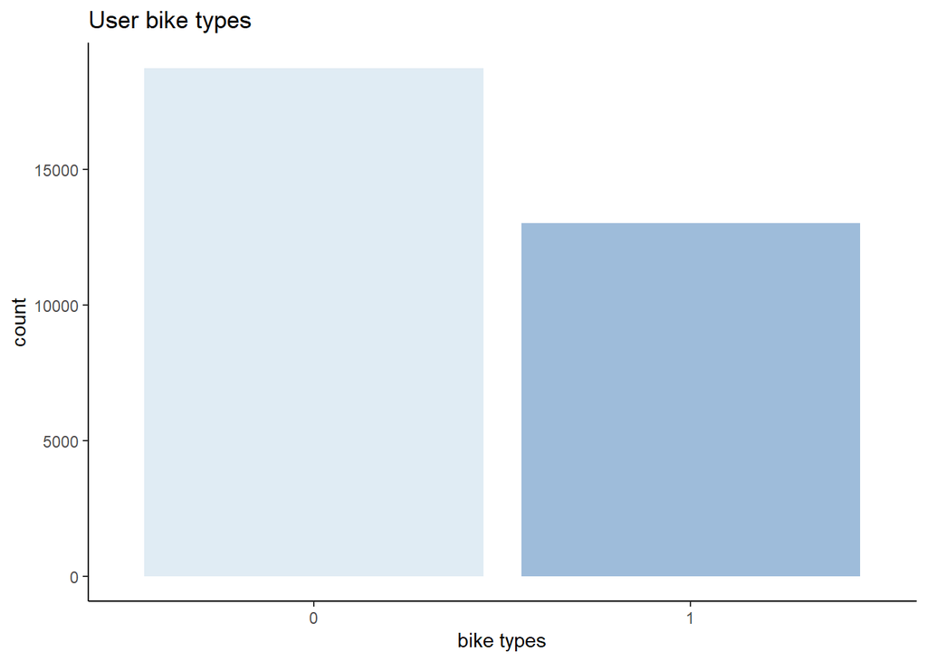

```r
ggplot(bike_RT_LR, aes(rideable_type, fill = rideable_type))+
  geom_bar()+
  scale_fill_brewer(palette = "BuPu")+
  guides(fill="none")+
  labs(title = "User bike types", x= "bike types")+
  theme_classic()
```

We splitted the data for training and testing in 75% and 25% split respectively.

```r
#Test and train split

set.seed(333)

bike_RT_LR_sample <- sample(2, nrow(bike_RT_LR), replace=TRUE, prob=c(0.75, 0.25))

bike_RT_LR_train_X <- bike_RT_LR[bike_RT_LR_sample==1, 2:8]
bike_RT_LR_test_X <- bike_RT_LR[bike_RT_LR_sample==2, 2:8]

bike_RT_LR_train_Y <- bike_RT_LR[bike_RT_LR_sample==1, 1]
bike_RT_LR_test_Y <- bike_RT_LR[bike_RT_LR_sample==2, 1]

print("Training data")
```

```
## [1] "Training data"
```

```r
print(head(bike_RT_LR_train_X))
```

```
##   start_station_id end_station_id member_casual startingm endingm   Total_Time
## 1                5              5             1      1018    1018   0.03333333
## 2               54            110             0       791     825  34.38333333
## 4               54             54             1        50      59   8.96666667
## 5               54             54             1      1389    1400  10.96666667
## 6               23             93             0      1056    1074  18.50000000
## 7               23             93             0      1054    1250 196.50000000
##   days
## 1  Mon
## 2  Wed
## 4  Fri
## 5  Thu
## 6  Sun
## 7  Sun
```

We applied the Logistic model with these features- start_station_id, end_station_id, Total_Time, member_casual, startingm, endingm and days

```r
# Logistic model
Bike_Type_Logit <- glm(bike_RT_LR_train_Y ~ start_station_id+ end_station_id+Total_Time*member_casual+ startingm*days +endingm , data = bike_RT_LR_train_X, family = "binomial")

print(summary(Bike_Type_Logit))
```

[output not shown]

## Model Evaluation

After running the models, we evaluated the model based on the following:

1. Deviance test
2. AUC
3. Accuracy, Precision and Recall at different cut-offs
1. **Deviance test**

   Null deviance: 32372 on 23911 degrees of freedom

   Residual deviance: 30525 on 23716 degrees of freedom

```r
pchisq(30048-22143, 28324-21948, lower.tail=F)
```

```
## [1] 1.146633e-36
```

2. **AUC**

   We further checked AUC of the model and got the following:

   Area under the curve for Training: 0.6576

   Area under the curve for Testing: 0.643

Results (Graph) for Training

```r
prob=predict(Bike_Type_Logit, type = "response")
a <- roc(bike_RT_LR_train_Y~prob)
```

```r
auc(a) # area-under-curve
```

```
## Area under the curve: 0.6576
```

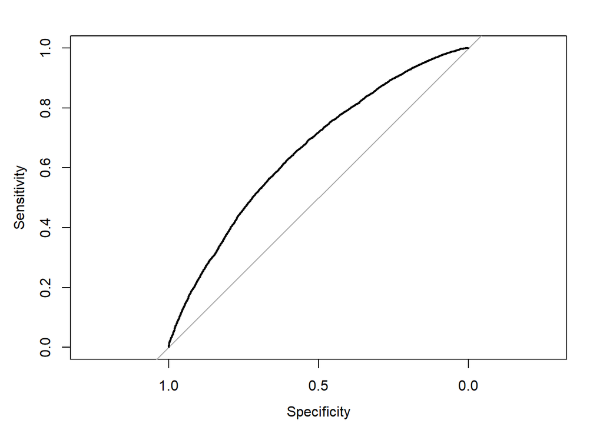

```r
plot(a)
```

Results (Graph) for Testing

```r
proc=predict(Bike_Type_Logit, type = "response", newdata = bike_RT_LR_test_X)
bike_RT_LR_test_X$proc=proc
b <- roc(bike_RT_LR_test_Y~proc)
print(b)
```

```
##
## Call:
## roc.formula(formula = bike_RT_LR_test_Y ~ proc)
##
## Data: proc in 4634 controls (bike_RT_LR_test_Y 0) < 3214 cases (bike_RT_LR_test_Y 1).
## Area under the curve: 0.643
```

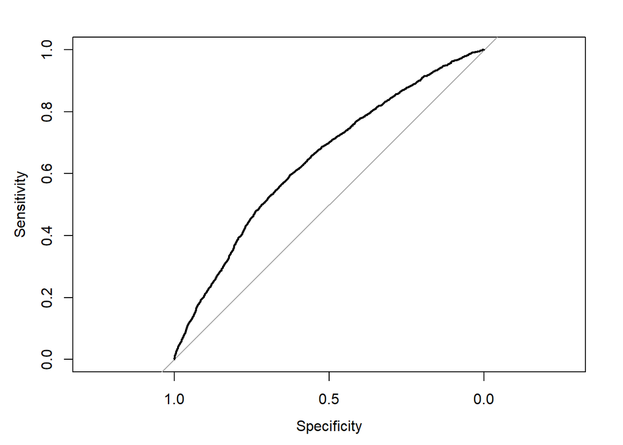

```r
plot(b)
```

3. **Accuracy, Precision and Recall at different cut-offs**

   We got the most accurate results at 0.5 and 0.4 cut offs.

### Results at 0.5 cut-off

```r
logitpredict.5 <- predict(Bike_Type_Logit, newdata = bike_RT_LR_test_X, type = "response") > 0.50

defult <- ifelse(logitpredict.5 =="TRUE", 1, 0)
crossTable = table(bike_RT_LR_test_Y,defult)
t <- as.data.frame(crossTable)
print(crossTable)
```

```
##                  defult
## bike_RT_LR_test_Y    0    1
##                 0 3832  802
##                 1 2179 1035
```

Below is the plot of confusion matrix at 0.5 cut off

[figure not shown]

```r
ggplot(data =  t, mapping = aes(x = defult, y = bike_RT_LR_test_Y)) +
  geom_tile(aes(fill = Freq), colour = "white") +
  geom_text(aes(label = sprintf("%1.0f", Freq)), vjust = 1) +
  scale_fill_gradient(low = "#98c1d9", high = "#8f2d56") +
  theme_bw() +
  theme(legend.position = "none") +
  labs(title = "Confution Matrix with Cutoff at 0.05")+
  xlab( "predected")+
  ylab( "original")
```

For **0.5 cut-off**, We got:

```r
format(100*(crossTable[1,1]+crossTable[2,2])/sum(crossTable), digits=4)
```

```
## [1] "62.02"
```

### Results at 0.4 cut-off

```r
logitpredict.4 <- predict(Bike_Type_Logit, newdata = bike_RT_LR_test_X, type = "response") > 0.4
defult2 <- ifelse(logitpredict.4 =="TRUE", 1, 0)
crossTable4 = table(bike_RT_LR_test_Y,defult2)
d <- as.data.frame(crossTable4)
print(crossTable4)
```

```
##                  defult2
## bike_RT_LR_test_Y    0    1
##                 0 2706 1928
##                 1 1194 2020
```

Below is the plot of confusion matrix at 0.4 cut-off

[figure not shown]

```r
ggplot(data = d , mapping = aes(x = defult2, y = bike_RT_LR_test_Y)) +
  geom_tile(aes(fill = Freq), colour = "white") +
  geom_text(aes(label = sprintf("%1.0f", Freq)), vjust = 1) +
  scale_fill_gradient(low = "#98c1d9", high = "#8f2d56") +
  theme_bw() +
  theme(legend.position = "none")+
  labs(title = "Confution Matrix with Cutoff at 0.04")+
  xlab( "predected")+
  ylab( "original")
```

- *Accuracy* as 60.22%
- *Precision* as 0.5116
- *Recall* as 0.6285

```r
format(100*(crossTable4[1,1]+crossTable4[2,2])/sum(crossTable4), digits=4)
```

```
## [1] "60.22"
```

**Predicting with values**

We predicted if the start_station_id= “15”, end_station_id = “11”, Total_Time = 2, member_casual = “0”, startingm = 80, days = “Sun”, endingm = 100.

We got the following result:

```r
glm1 <- data.frame(start_station_id= "15", end_station_id = "11", Total_Time = 2, member_casual = "0", startingm = 80, days = "Sun", endingm = 100)
predict(Bike_Type_Logit, newdata=glm1)
```

```
##         1
## 0.3305889
```

## Model-2: KNN (for Bike Type)

In the first step, we selected the features we need for the KNN model, which are- ‘member_casual’,‘rideable_type’, ‘Total_Time’, ‘start_station_id’, ‘end_station_id’, ‘startingm’ and ‘endingm’

```r
#Copying data for the model
df_knn <- data.frame(bike2)

print(head(df_knn))
```

```
##   rideable_type start_station_id end_station_id member_casual startingm endingm
## 1             0                5              5             1      1018    1018
## 2             0               54            110             0       791     825
## 3             0               15             26             1       627     633
## 4             1               54             54             1        50      59
## 5             1               54             54             1      1389    1400
## 6             0               23             93             0      1056    1074
##    Total_Time days start_hour  Time_range
## 1  0.03333333  Mon         16   Afternoon
## 2 34.38333333  Wed         13   Afternoon
## 3  5.53333333  Mon         10     Morning
## 4  8.96666667  Fri          0 Before dawn
## 5 10.96666667  Thu         23       Night
## 6 18.50000000  Sun         17   Afternoon
```

```r
#selecting the features needed for the model
selected_features <- c('member_casual','rideable_type', 'Total_Time', 'start_station_id', 'end_station_id', 'startingm','endingm')

df_rt_knn <- df_knn[,(names(df_knn) %in% selected_features)]
```

Then, we converted the format of each feature into numeric

```r
#df_rt_knn <- as.data.frame(df_knn[-c(7)])
df_rt_knn$rideable_type <- as.numeric(df_knn$rideable_type)
df_rt_knn$Total_Time <- as.numeric(df_knn$Total_Time)
df_rt_knn$member_casual <- as.numeric(df_knn$member_casual)
df_rt_knn$start_station_id <- as.numeric(df_knn$start_station_id)
df_rt_knn$end_station_id <- as.numeric(df_knn$end_station_id)
df_rt_knn$startingm <- as.numeric(df_knn$startingm)
df_rt_knn$endingm <- as.numeric(df_knn$endingm)

print(str(df_rt_knn))
```

```
## 'data.frame':    31760 obs. of  7 variables:
##  $ rideable_type   : num  1 1 1 2 2 1 1 1 1 1 ...
##  $ start_station_id: num  5 40 15 40 40 23 23 55 29 40 ...
##  $ end_station_id  : num  5 84 26 40 40 74 74 56 14 54 ...
##  $ member_casual   : num  2 1 2 2 2 1 1 1 2 2 ...
##  $ startingm       : num  1018 791 627 50 1389 ...
##  $ endingm         : num  1018 825 633 59 1400 ...
##  $ Total_Time      : num  0.0333 34.3833 5.5333 8.9667 10.9667 ...
## NULL
```

We divided the data into training and testing dataset with 75% and 25% respectively

```r
scaleddf <- as.data.frame(scale(df_rt_knn[2:6], center = TRUE, scale = TRUE))
set.seed(333)
df_sample_rt <- sample(2, nrow(df_rt_knn), replace=TRUE, prob=c(0.75, 0.25))


DF_Rt_train_X <- df_rt_knn[df_sample_rt==1, 2:6]
DF_Rt_test_X <- df_rt_knn[df_sample_rt==2, 2:6]


DF_Rt_train_y <- df_rt_knn[df_sample_rt==1, 1]
DF_Rt_test_y <- df_rt_knn[df_sample_rt==2, 1]

print("Training data")
```

```
## [1] "Training data"
```

```r
print(head(DF_Rt_train_X))
```

```
##   start_station_id end_station_id member_casual startingm endingm
## 1                5              5             2      1018    1018
## 2               40             84             1       791     825
## 4               40             40             2        50      59
## 5               40             40             2      1389    1400
## 6               23             74             1      1056    1074
## 7               23             74             1      1054    1250
```

Finaly, we ran the KNN model using our Train and Test data at K=3

```r
knn1 <- knn(train=DF_Rt_train_X, test=DF_Rt_test_X, cl=DF_Rt_train_y, k=3)

print(summary(knn1))
```

```
##    1    2
## 4844 3004
```

KNN Cross table:

```r
# create an empty dataframe to store the results from confusion matrices
ResultDf = data.frame( k=numeric(0), Total.Accuracy= numeric(0), row.names = NULL )
kval = 3
knn_pred <- knn(train = DF_Rt_train_X, test = DF_Rt_test_X, cl=DF_Rt_train_y, k=kval)

knn_crosst <- gmodels::CrossTable(DF_Rt_test_y, train = knn_pred, prop.chisq = FALSE)
```

```
##
##
##    Cell Contents
## |-------------------------|
## |                       N |
## |         N / Table Total |
## |-------------------------|
##
##
## Total Observations in Table:  7848
##
##
##           |         1 |         2 |
##           |-----------|-----------|
##           |      4634 |      3214 |
##           |     0.590 |     0.410 |
##           |-----------|-----------|
##
##
##
##
```

```r
print( paste("k = ", kval) )
```

```
## [1] "k =  3"
```

```r
knn_crosst
```

```
## $t
##         1    2
## [1,] 4634 3214
##
## $prop.row
##              1         2
## [1,] 0.5904689 0.4095311
##
## $prop.col
##      1 2
## [1,] 1 1
##
## $prop.tbl
##              1         2
## [1,] 0.5904689 0.4095311
```

KNN confusion matrix and accuracy at K=3

```r
library(caret)

cm <- confusionMatrix(knn_pred, reference = as.factor(DF_Rt_test_y))


cmaccu = cm$overall['Accuracy']
print( paste("Total Accuracy = ", cmaccu ) )
```

```
## [1] "Total Accuracy =  0.609582059123344"
```

```r
cmt = data.frame(k=kval, Total.Accuracy = cmaccu, row.names = NULL )

ResultDf = rbind(ResultDf, cmt)
print(as.matrix(cm), title = paste("ConfusionMatrix for k = ",kval ) )
```

```
##      1    2
## 1 3207 1637
## 2 1427 1577
```

## Model Evaluation

Evaluation table for K=3

```r
print(data.frame(cm$byClass), title=paste("k = ",kval))
```

```
##                      cm.byClass
## Sensitivity           0.6920587
## Specificity           0.4906658
## Pos Pred Value        0.6620562
## Neg Pred Value        0.5249667
## Precision             0.6620562
## Recall                0.6920587
## F1                    0.6767250
## Prevalence            0.5904689
## Detection Rate        0.4086391
## Detection Prevalence  0.6172273
## Balanced Accuracy     0.5913623
```

Model Evaluation for Different K-values

```r
for (kval in 4:11) {
  knn_pred <- knn(train = DF_Rt_train_X, test = DF_Rt_test_X, cl=DF_Rt_train_y, k=kval)
  knn_crosst <- CrossTable(DF_Rt_test_y, knn_pred, prop.chisq = FALSE)
  print( paste("k = ", kval) )
  knn_crosst
  #
  cm = confusionMatrix(knn_pred, reference = as.factor(DF_Rt_test_y))

  cmaccu = cm$overall['Accuracy']
  print( paste("Total Accuracy = ", cmaccu ) )

  cmt = data.frame(k=kval, Total.Accuracy = cmaccu, row.names = NULL )

  ResultDf = rbind(ResultDf, cmt)
  print(as.matrix(cm), title = paste("ConfusionMatrix for k = ",kval ) )
  print(data.frame(cm$byClass), title=paste("k = ",kval))
}
```

```
##
##
##    Cell Contents
## |-------------------------|
## |                       N |
## |           N / Row Total |
## |           N / Col Total |
## |         N / Table Total |
## |-------------------------|
##
##
## Total Observations in Table:  7848
##
##
##              | knn_pred
## DF_Rt_test_y |         1 |         2 | Row Total |
## -------------|-----------|-----------|-----------|
##            1 |      3783 |       851 |      4634 |
##              |     0.816 |     0.184 |     0.590 |
##              |     0.634 |     0.452 |           |
##              |     0.482 |     0.108 |           |
## -------------|-----------|-----------|-----------|
##            2 |      2183 |      1031 |      3214 |
##              |     0.679 |     0.321 |     0.410 |
##              |     0.366 |     0.548 |           |
##              |     0.278 |     0.131 |           |
## -------------|-----------|-----------|-----------|
## Column Total |      5966 |      1882 |      7848 |
##              |     0.760 |     0.240 |           |
## -------------|-----------|-----------|-----------|
##
##
## [1] "k =  4"
## [1] "Total Accuracy =  0.613404689092762"
##      1    2
## 1 3783 2183
## 2  851 1031
##                      cm.byClass
## Sensitivity           0.8163574
## Specificity           0.3207841
```

[output cut: 337 more lines]

```
##      1    2
## 1 3420 2019
## 2 1214 1195
##                      cm.byClass
## Sensitivity           0.7380233
## Specificity           0.3718108
## Pos Pred Value        0.6287921
## Neg Pred Value        0.4960565
## Precision             0.6287921
## Recall                0.7380233
## F1                    0.6790430
## Prevalence            0.5904689
## Detection Rate        0.4357798
## Detection Prevalence  0.6930428
## Balanced Accuracy     0.5549171
```

Checking the best K-value

```r
print(ResultDf)
```

```
##    k Total.Accuracy
## 1  3      0.6095821
## 2  4      0.6134047
## 3  5      0.6004077
## 4  6      0.6065240
## 5  7      0.5876656
## 6  8      0.5972222
## 7  9      0.5886850
## 8 10      0.5965851
## 9 11      0.5880479
```

## Conclusion (smart Q-2)

But we would choose *Logistic Regression* as our final model to give it to the company as accuracy for both the model is almost similar but, KNN is slow in real time as it have to keep track of all the training data and find the neighbor nodes, whereas LR can easily extract output from the tuned theta coefficients.

# SMART Question 3.

What type of customer (Annual membership or Casual) will travel from a certain station to another, while using a particular bike or at certain time etc?

We built 1 model for this question

## Model-1: Logistic Regression (for Customer Type)

Firstly, we made the member_casual column as the first column in the dataset to make it easy while splitting the data for the modelling

```r
#Copying data for the model
df <- data.frame(bike2)


#making rideable_type the first column
colnames(df)
```

```
##  [1] "rideable_type"    "start_station_id" "end_station_id"   "member_casual"
##  [5] "startingm"        "endingm"          "Total_Time"       "days"
##  [9] "start_hour"       "Time_range"
```

```r
df <- df %>%
  select('member_casual', everything())

print(head(df))
```

```
##   member_casual rideable_type start_station_id end_station_id startingm endingm
## 1             1             0                5              5      1018    1018
## 2             0             0               54            110       791     825
## 3             1             0               15             26       627     633
## 4             1             1               54             54        50      59
## 5             1             1               54             54      1389    1400
## 6             0             0               23             93      1056    1074
##    Total_Time days start_hour  Time_range
## 1  0.03333333  Mon         16   Afternoon
## 2 34.38333333  Wed         13   Afternoon
## 3  5.53333333  Mon         10     Morning
## 4  8.96666667  Fri          0 Before dawn
## 5 10.96666667  Thu         23       Night
## 6 18.50000000  Sun         17   Afternoon
```

We further Checked, if we have unbalanced data. We found that the data was balanced and we could use it for our modeling

```r
df%>%group_by(member_casual)%>%
  summarise(count = n())
```

```
## # A tibble: 2 × 2
##   member_casual count
##   <fct>         <int>
## 1 0             19589
## 2 1             12171
```

```r
df %>% count(member_casual)
```

```
##   member_casual     n
## 1             0 19589
## 2             1 12171
```

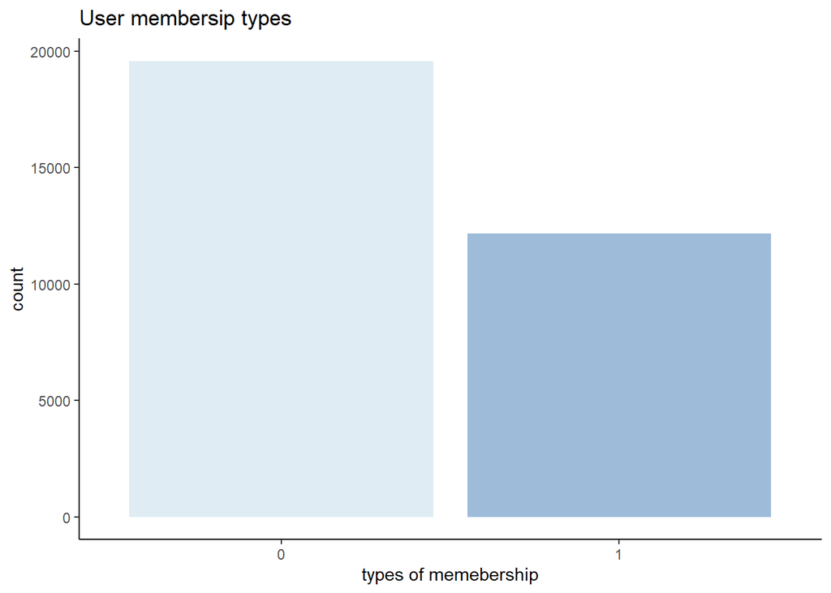

```r
ggplot(df, aes(member_casual, fill = member_casual))+
  geom_bar()+
  scale_fill_brewer(palette = "BuPu")+
  guides(fill="none")+
  labs(title = "User membersip types", x= "types of memebership")+
  theme_classic()
```

We divided the data for training and testing in 75% and 25% split respectively.

```r
set.seed(321)
df_sample <- sample(2, nrow(df), replace=TRUE, prob=c(0.75, 0.25))


train_X <- df[df_sample==1, 2:8]
test_X <- df[df_sample==2, 2:8]


train_y <- df[df_sample==1, 1]
test_y <- df[df_sample==2, 1]

print("Training data")
```

```
## [1] "Training data"
```

```r
print(head(train_X))
```

```
##   rideable_type start_station_id end_station_id startingm endingm Total_Time
## 3             0               15             26       627     633   5.533333
## 4             1               54             54        50      59   8.966667
## 5             1               54             54      1389    1400  10.966667
## 6             0               23             93      1056    1074  18.500000
## 7             0               23             93      1054    1250 196.500000
## 8             0               73             74       612     693  80.666667
##   days
## 3  Mon
## 4  Fri
## 5  Thu
## 6  Sun
## 7  Sun
## 8  Sun
```

We applied the Logistic model with these features- start_station_id, end_station_id, Total_Time, rideable_type, startingm, endingm and days

```r
#deleted start_station_id and Wed coz the model says it is not much predictable
customerLogit <- glm(train_y ~ end_station_id+Total_Time+rideable_type+ startingm*days + endingm + start_station_id, data = train_X, family = "binomial")
summary(customerLogit)
```

```
##
## Call:
## glm(formula = train_y ~ end_station_id + Total_Time + rideable_type +
##     startingm * days + endingm + start_station_id, family = "binomial",
##     data = train_X)
##
## Deviance Residuals:
##     Min       1Q   Median       3Q      Max
## -2.8648  -0.8564  -0.3912   0.9169   8.4904
##
## Coefficients:
##                       Estimate Std. Error z value Pr(>|z|)
## (Intercept)         -4.223e-01  1.609e-01  -2.625 0.008663 **
## end_station_id2      3.622e-01  1.408e-01   2.573 0.010096 *
## end_station_id3      9.223e-01  1.434e-01   6.430 1.27e-10 ***
## end_station_id4      3.198e-01  1.300e-01   2.460 0.013899 *
## end_station_id5      7.897e-01  1.908e-01   4.139 3.49e-05 ***
## end_station_id6      1.242e+00  1.358e-01   9.146  < 2e-16 ***
## end_station_id7      6.005e-01  1.400e-01   4.290 1.78e-05 ***
## end_station_id8      1.323e+00  1.513e-01   8.739  < 2e-16 ***
## end_station_id9      6.851e-01  1.431e-01   4.786 1.70e-06 ***
## end_station_id10     8.215e-01  1.331e-01   6.170 6.82e-10 ***
## end_station_id11     3.054e-01  1.627e-01   1.877 0.060510 .
## end_station_id12     1.490e-01  1.931e-01   0.772 0.440313
## end_station_id13     7.900e-01  1.302e-01   6.068 1.29e-09 ***
## end_station_id14     1.548e+00  1.589e-01   9.743  < 2e-16 ***
## end_station_id15     1.127e+00  2.313e-01   4.872 1.11e-06 ***
## end_station_id16    -1.755e-01  1.932e-01  -0.909 0.363561
## end_station_id17     5.378e-01  1.687e-01   3.189 0.001430 **
## end_station_id18     4.011e-01  1.368e-01   2.932 0.003367 **
## end_station_id19     5.698e-02  1.549e-01   0.368 0.712930
## end_station_id20     7.252e-01  1.268e-01   5.720 1.06e-08 ***
## end_station_id21    -8.926e-02  2.291e-01  -0.390 0.696833
## end_station_id22     8.641e-01  1.432e-01   6.036 1.58e-09 ***
## end_station_id23     4.434e-01  1.151e-01   3.852 0.000117 ***
## end_station_id24     5.661e-01  1.316e-01   4.302 1.69e-05 ***
## end_station_id25     1.336e+00  2.079e-01   6.425 1.32e-10 ***
## end_station_id26     4.335e-01  1.604e-01   2.703 0.006882 **
## end_station_id27     1.320e+00  2.321e-01   5.685 1.31e-08 ***
## end_station_id28     3.758e-01  1.873e-01   2.006 0.044871 *
```

[output cut: 162 more lines]

```
## startingm:daysSat    5.085e-04  1.684e-04   3.020 0.002531 **
## startingm:daysSun    9.161e-04  1.719e-04   5.328 9.94e-08 ***
## startingm:daysThu   -1.221e-04  1.964e-04  -0.622 0.534160
## startingm:daysTue    8.149e-06  1.994e-04   0.041 0.967400
## startingm:daysWed   -1.785e-04  1.950e-04  -0.915 0.360150
## ---
## Signif. codes:  0 '***' 0.001 '**' 0.01 '*' 0.05 '.' 0.1 ' ' 1
##
## (Dispersion parameter for binomial family taken to be 1)
##
##     Null deviance: 31743  on 23805  degrees of freedom
## Residual deviance: 24881  on 23611  degrees of freedom
## AIC: 25271
##
## Number of Fisher Scoring iterations: 11
```

## Model Evaluation

After running the models, We evaluate the model to check the following:

1. Deviance test
2. AUC
3. Accuracy, Precision and Recall at different cut-offs
1. **Deviance test**

   Null deviance: 31743 on 23805 degrees of freedom

   Residual deviance: 24881 on 23611 degrees of freedom

```r
pchisq(31743-23805, 24881-23611, lower.tail=F)
```

```
## [1] 0
```

The Chi-Square p-value is less than 0.05. Therefore, we would conclude that the model is highly useful for predicting the probability that a given individual defaults.

2. **AUC**

   Area under the curve for Training: 0.8081

   Area under the curve for Testing: 0.8019

Results (Graph) for Training

```r
prob=predict(customerLogit, type = "response")
e <- roc(train_y~prob)
```

```r
auc(e) # area-under-curve
```

```
## Area under the curve: 0.8081
```

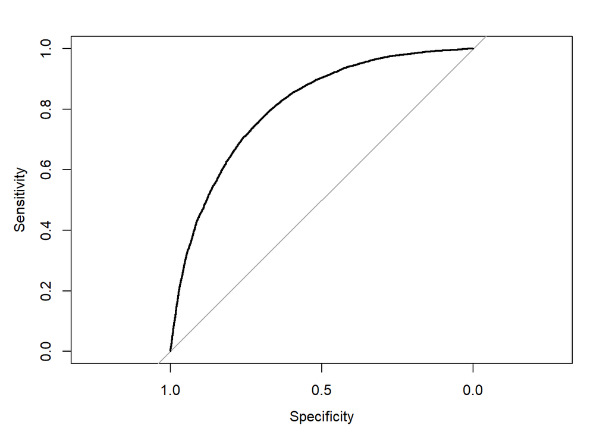

```r
plot(e)
```

Results (Graph) for Testing

```r
proc=predict(customerLogit, type = "response", newdata = test_X)
test_X$proc=proc
roc <- roc(test_y~proc)
print(roc)
```

```
##
## Call:
## roc.formula(formula = test_y ~ proc)
##
## Data: proc in 4961 controls (test_y 0) < 2993 cases (test_y 1).
## Area under the curve: 0.8019
```

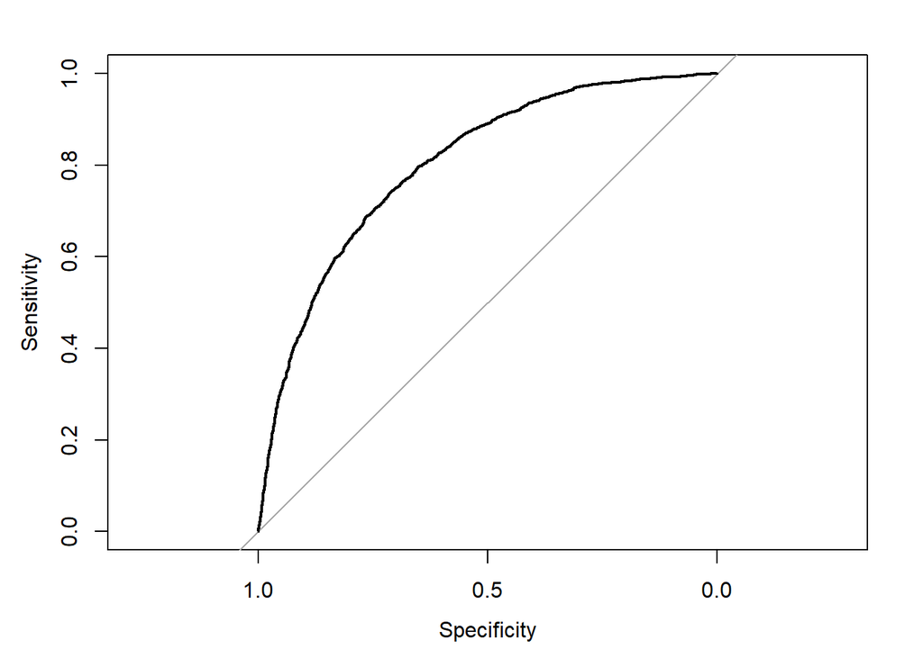

```r
plot(roc)
```

3. **Accuracy, Precision and Recall at different cut-offs**

   Then we checked the the accuracy at different cut offs. We got the most accurate results at 0.5 and 0.4 cut off

### Results at 0.5 cut-off

```r
logitpredict.5 <- predict(customerLogit, newdata = test_X, type = "response") > 0.5

## I don't know if members are 1 or 0
defult <- ifelse(logitpredict.5 =="TRUE", 1, 0)
crossTable = table(test_y, defult)
t <- as.data.frame(crossTable)
crossTable
```

```
##       defult
## test_y    0    1
##      0 4123  838
##      1 1205 1788
```

Below is the plot of confusion matrix at 0.5 cut

[figure not shown]

```r
ggplot(data =  t, mapping = aes(x = defult, y = test_y)) +
  geom_tile(aes(fill = Freq), colour = "white") +
  geom_text(aes(label = sprintf("%1.0f", Freq)), vjust = 1) +
  scale_fill_gradient(low = "#98c1d9", high = "#8f2d56") +
  theme_bw() +
  theme(legend.position = "none") +
  labs(title = "Confution Matrix with Cutoff at 0.05")+
  xlab( "predected")+
  ylab( "original")
```

For **0.5 cut-off**, We got:

- *Accuracy* as 74.31%
- *Precision* as 0.6808
- *Recall* as 0.5973

```r
format(100*(crossTable[1,1]+crossTable[2,2])/sum(crossTable), digits=4)
```

```
## [1] "74.31"
```

### Results at 0.4 cut-off

```r
logitpredict.4 <- predict(customerLogit, newdata = test_X, type = "response") > 0.4
defult2 <- ifelse(logitpredict.4 =="TRUE", 1, 0)
crossTable4 = table(test_y, defult2)
d <- as.data.frame(crossTable4)
crossTable4
```

```
##       defult2
## test_y    0    1
##      0 3557 1404
##      1  799 2194
```

Below is the plot of confusion matrix at 0.4 cut-off

[figure not shown]

```r
ggplot(data = d , mapping = aes(x = defult2, y = test_y)) +
  geom_tile(aes(fill = Freq), colour = "white") +
  geom_text(aes(label = sprintf("%1.0f", Freq)), vjust = 1) +
  scale_fill_gradient(low = "#98c1d9", high = "#8f2d56") +
  theme_bw() +
  theme(legend.position = "none")+
  labs(title = "Confution Matrix with Cutoff at 0.04")+
  xlab( "predected")+
  ylab( "original")
```

- *Accuracy* as 72.3%
- *Precision* as 0.6097
- *Recall* as 0.7330

```r
format(100*(crossTable4[1,1]+crossTable4[2,2])/sum(crossTable4), digits=4)
```

```
## [1] "72.3"
```

## Conclusion (smart Q-3):

According to the confusion matrix the model can be considered as a good fit for predicting the `annual member` at 0.5 cut-off and is giving the accuracy of 74.31. To the interest of raising the profit of the company we are most interested in the `casual_customers` who has been predicted as `annual_customer`as they show the same behaviors of `annual_customers` therefore we argue that if the company target them, there is a high probability that they can be converted to the `annual_customer`.

# Final Conclusion and Recommendation

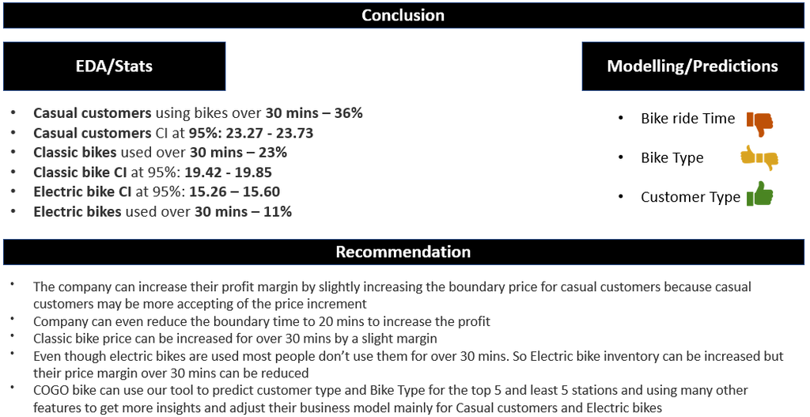

# Reference

1. https://cogobikeshare.com/pricing
2. https://www.r-bloggers.com/